# Risk Factor Analysis

## Outcome Variable

**Outcome Variable:** pers_wast

## Predictor Variables

**Intervention Variable:** parity

**Adjustment Set:**

- arm
- W_mage
- meducyrs
- feducyrs
- hhwealth_quart
- W_mhtcm
- vagbrth
- impsan
- delta_W_mage
- delta_meducyrs
- delta_feducyrs
- delta_hhwealth_quart
- delta_W_mhtcm
- delta_vagbrth
- delta_impsan

## Stratifying Variables

The analysis was stratified on these variable(s):

- agecat
- studyid
- country

## Data Summary

| agecat | studyid | country | parity | pers_wast | n_cell | n |
| --- | --- | --- | --- | --- | --- | --- |
| 0-24 months | ki1000304b-SAS-CompFeed | INDIA | 1 | 0 | 378 | 1366 |
| 0-24 months | ki1000304b-SAS-CompFeed | INDIA | 1 | 1 | 30 | 1366 |
| 0-24 months | ki1000304b-SAS-CompFeed | INDIA | 2 | 0 | 291 | 1366 |
| 0-24 months | ki1000304b-SAS-CompFeed | INDIA | 2 | 1 | 27 | 1366 |
| 0-24 months | ki1000304b-SAS-CompFeed | INDIA | 3+ | 0 | 583 | 1366 |
| 0-24 months | ki1000304b-SAS-CompFeed | INDIA | 3+ | 1 | 57 | 1366 |
| 0-24 months | ki1000304b-SAS-FoodSuppl | INDIA | 1 | 0 | 62 | 373 |
| 0-24 months | ki1000304b-SAS-FoodSuppl | INDIA | 1 | 1 | 7 | 373 |
| 0-24 months | ki1000304b-SAS-FoodSuppl | INDIA | 2 | 0 | 76 | 373 |
| 0-24 months | ki1000304b-SAS-FoodSuppl | INDIA | 2 | 1 | 11 | 373 |
| 0-24 months | ki1000304b-SAS-FoodSuppl | INDIA | 3+ | 0 | 171 | 373 |
| 0-24 months | ki1000304b-SAS-FoodSuppl | INDIA | 3+ | 1 | 46 | 373 |
| 0-24 months | ki1017093b-PROVIDE | BANGLADESH | 1 | 0 | 237 | 640 |
| 0-24 months | ki1017093b-PROVIDE | BANGLADESH | 1 | 1 | 4 | 640 |
| 0-24 months | ki1017093b-PROVIDE | BANGLADESH | 2 | 0 | 223 | 640 |
| 0-24 months | ki1017093b-PROVIDE | BANGLADESH | 2 | 1 | 4 | 640 |
| 0-24 months | ki1017093b-PROVIDE | BANGLADESH | 3+ | 0 | 165 | 640 |
| 0-24 months | ki1017093b-PROVIDE | BANGLADESH | 3+ | 1 | 7 | 640 |
| 0-24 months | ki1066203-TanzaniaChild2 | TANZANIA, UNITED REPUBLIC OF | 1 | 0 | 710 | 2132 |
| 0-24 months | ki1066203-TanzaniaChild2 | TANZANIA, UNITED REPUBLIC OF | 1 | 1 | 18 | 2132 |
| 0-24 months | ki1066203-TanzaniaChild2 | TANZANIA, UNITED REPUBLIC OF | 2 | 0 | 683 | 2132 |
| 0-24 months | ki1066203-TanzaniaChild2 | TANZANIA, UNITED REPUBLIC OF | 2 | 1 | 20 | 2132 |
| 0-24 months | ki1066203-TanzaniaChild2 | TANZANIA, UNITED REPUBLIC OF | 3+ | 0 | 682 | 2132 |
| 0-24 months | ki1066203-TanzaniaChild2 | TANZANIA, UNITED REPUBLIC OF | 3+ | 1 | 19 | 2132 |
| 0-24 months | ki1101329-Keneba | GAMBIA | 1 | 0 | 220 | 1850 |
| 0-24 months | ki1101329-Keneba | GAMBIA | 1 | 1 | 9 | 1850 |
| 0-24 months | ki1101329-Keneba | GAMBIA | 2 | 0 | 190 | 1850 |
| 0-24 months | ki1101329-Keneba | GAMBIA | 2 | 1 | 9 | 1850 |
| 0-24 months | ki1101329-Keneba | GAMBIA | 3+ | 0 | 1350 | 1850 |
| 0-24 months | ki1101329-Keneba | GAMBIA | 3+ | 1 | 72 | 1850 |

[output cut: 144 more lines]

The following strata were considered:

- agecat: 0-24 months, studyid: ki1000304b-SAS-CompFeed, country: INDIA
- agecat: 0-24 months, studyid: ki1000304b-SAS-FoodSuppl, country: INDIA
- agecat: 0-24 months, studyid: ki1017093b-PROVIDE, country: BANGLADESH
- agecat: 0-24 months, studyid: ki1066203-TanzaniaChild2, country: TANZANIA, UNITED REPUBLIC OF
- agecat: 0-24 months, studyid: ki1101329-Keneba, country: GAMBIA
- agecat: 0-24 months, studyid: ki1113344-GMS-Nepal, country: NEPAL
- agecat: 0-24 months, studyid: ki1126311-ZVITAMBO, country: ZIMBABWE
- agecat: 0-24 months, studyid: ki1135781-COHORTS, country: GUATEMALA
- agecat: 0-24 months, studyid: ki1135781-COHORTS, country: INDIA
- agecat: 0-24 months, studyid: ki1135781-COHORTS, country: PHILIPPINES
- agecat: 0-24 months, studyid: kiGH5241-JiVitA-3, country: BANGLADESH
- agecat: 0-6 months, studyid: ki1017093b-PROVIDE, country: BANGLADESH
- agecat: 0-6 months, studyid: ki1066203-TanzaniaChild2, country: TANZANIA, UNITED REPUBLIC OF
- agecat: 0-6 months, studyid: ki1101329-Keneba, country: GAMBIA
- agecat: 0-6 months, studyid: ki1113344-GMS-Nepal, country: NEPAL
- agecat: 0-6 months, studyid: ki1126311-ZVITAMBO, country: ZIMBABWE
- agecat: 0-6 months, studyid: ki1135781-COHORTS, country: PHILIPPINES
- agecat: 0-6 months, studyid: kiGH5241-JiVitA-3, country: BANGLADESH
- agecat: 6-24 months, studyid: ki1000304b-SAS-CompFeed, country: INDIA
- agecat: 6-24 months, studyid: ki1000304b-SAS-FoodSuppl, country: INDIA
- agecat: 6-24 months, studyid: ki1017093b-PROVIDE, country: BANGLADESH
- agecat: 6-24 months, studyid: ki1066203-TanzaniaChild2, country: TANZANIA, UNITED REPUBLIC OF
- agecat: 6-24 months, studyid: ki1101329-Keneba, country: GAMBIA
- agecat: 6-24 months, studyid: ki1113344-GMS-Nepal, country: NEPAL
- agecat: 6-24 months, studyid: ki1126311-ZVITAMBO, country: ZIMBABWE
- agecat: 6-24 months, studyid: ki1135781-COHORTS, country: GUATEMALA
- agecat: 6-24 months, studyid: ki1135781-COHORTS, country: INDIA
- agecat: 6-24 months, studyid: ki1135781-COHORTS, country: PHILIPPINES
- agecat: 6-24 months, studyid: kiGH5241-JiVitA-3, country: BANGLADESH

### Dropped Strata

Some strata were dropped due to rare outcomes:

- agecat: 0-24 months, studyid: ki1017093b-PROVIDE, country: BANGLADESH
- agecat: 0-24 months, studyid: ki1135781-COHORTS, country: GUATEMALA
- agecat: 0-6 months, studyid: ki1017093b-PROVIDE, country: BANGLADESH
- agecat: 0-6 months, studyid: ki1101329-Keneba, country: GAMBIA
- agecat: 0-6 months, studyid: ki1126311-ZVITAMBO, country: ZIMBABWE
- agecat: 0-6 months, studyid: kiGH5241-JiVitA-3, country: BANGLADESH
- agecat: 6-24 months, studyid: ki1017093b-PROVIDE, country: BANGLADESH
- agecat: 6-24 months, studyid: ki1135781-COHORTS, country: GUATEMALA

## Methods Detail

We’re interested in the causal parameters $E[Y_a]$ for all values of $a \in \mathcal{A}$. These parameters represent the mean outcome if, possibly contrary to fact, we intervened to set all units to have $A=a$. Under the randomization and positivity assumptions, these are identified by the statistical parameters $\psi_a=E_W[E_{Y|A,W}(Y|A=a,W)]$. In addition, we’re interested in the mean of $Y$, $E[Y]$ under no intervention (the observed mean). We will estimate these parameters by using SuperLearner to fit the relevant likelihood factors – $E_{Y|A,W}(Y|A=a,W)$ and $p(A=a|W)$, and then updating our likelihood fit using a joint TMLE.

For unadjusted analyses ($W=\{\}$), initial likelihoods were estimated using Lrnr_glm to estimate the simple $E(Y|A)$ and Lrnr_mean to estimate $p(A)$. For adjusted analyses, a small library containing Lrnr_glmnet, Lrnr_xgboost, and Lrnr_mean was used.

Having estimated these parameters, we will then use the delta method to estimate relative risks and attributable risks relative to a prespecified baseline level of $A$.

# Results Detail

## Results Plots

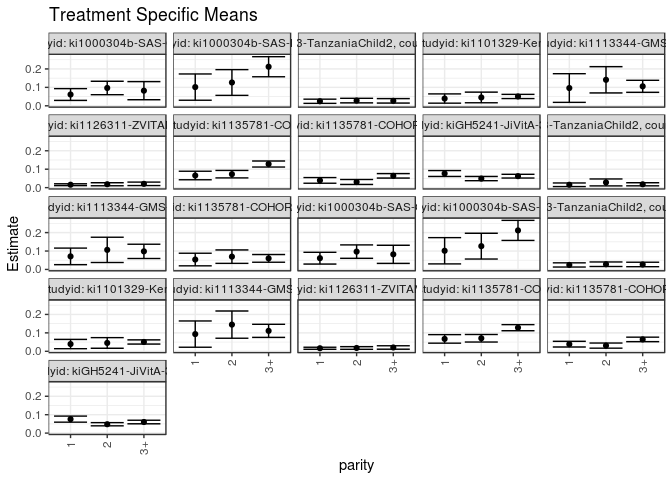

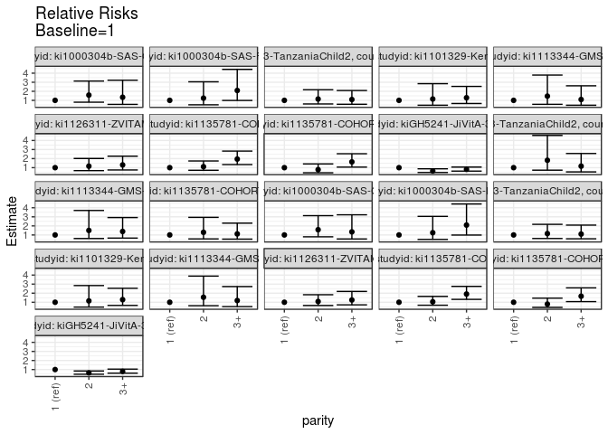

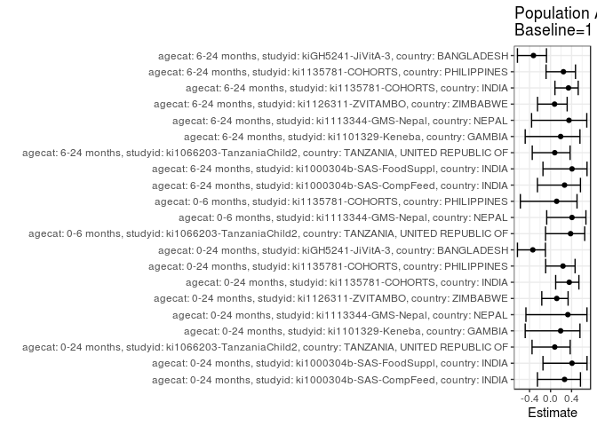

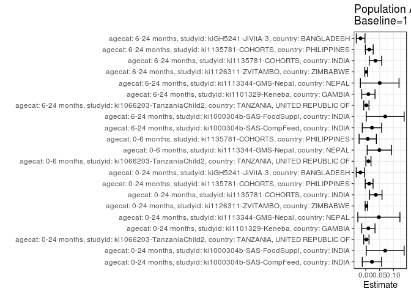

## Results Table

### Parameter: TSM

| agecat | studyid | country | intervention_level | baseline_level | estimate | ci_lower | ci_upper |
| --- | --- | --- | --- | --- | --- | --- | --- |
| 0-24 months | ki1000304b-SAS-CompFeed | INDIA | 1 | NA | 0.0612154 | 0.0292447 | 0.0931861 |
| 0-24 months | ki1000304b-SAS-CompFeed | INDIA | 2 | NA | 0.0967276 | 0.0603010 | 0.1331541 |
| 0-24 months | ki1000304b-SAS-CompFeed | INDIA | 3+ | NA | 0.0820545 | 0.0328692 | 0.1312398 |
| 0-24 months | ki1000304b-SAS-FoodSuppl | INDIA | 1 | NA | 0.1014493 | 0.0301143 | 0.1727842 |
| 0-24 months | ki1000304b-SAS-FoodSuppl | INDIA | 2 | NA | 0.1264368 | 0.0565081 | 0.1963655 |
| 0-24 months | ki1000304b-SAS-FoodSuppl | INDIA | 3+ | NA | 0.2119816 | 0.1575290 | 0.2664341 |
| 0-24 months | ki1066203-TanzaniaChild2 | TANZANIA, UNITED REPUBLIC OF | 1 | NA | 0.0246073 | 0.0131688 | 0.0360458 |
| 0-24 months | ki1066203-TanzaniaChild2 | TANZANIA, UNITED REPUBLIC OF | 2 | NA | 0.0282231 | 0.0158684 | 0.0405779 |
| 0-24 months | ki1066203-TanzaniaChild2 | TANZANIA, UNITED REPUBLIC OF | 3+ | NA | 0.0268993 | 0.0147871 | 0.0390115 |
| 0-24 months | ki1101329-Keneba | GAMBIA | 1 | NA | 0.0393013 | 0.0141277 | 0.0644749 |
| 0-24 months | ki1101329-Keneba | GAMBIA | 2 | NA | 0.0452261 | 0.0163470 | 0.0741053 |
| 0-24 months | ki1101329-Keneba | GAMBIA | 3+ | NA | 0.0506329 | 0.0392344 | 0.0620315 |
| 0-24 months | ki1113344-GMS-Nepal | NEPAL | 1 | NA | 0.0963510 | 0.0185660 | 0.1741361 |
| 0-24 months | ki1113344-GMS-Nepal | NEPAL | 2 | NA | 0.1410399 | 0.0697395 | 0.2123402 |
| 0-24 months | ki1113344-GMS-Nepal | NEPAL | 3+ | NA | 0.1056210 | 0.0729865 | 0.1382555 |
| 0-24 months | ki1126311-ZVITAMBO | ZIMBABWE | 1 | NA | 0.0157797 | 0.0107688 | 0.0207907 |
| 0-24 months | ki1126311-ZVITAMBO | ZIMBABWE | 2 | NA | 0.0183727 | 0.0101624 | 0.0265829 |
| 0-24 months | ki1126311-ZVITAMBO | ZIMBABWE | 3+ | NA | 0.0205542 | 0.0112364 | 0.0298720 |
| 0-24 months | ki1135781-COHORTS | INDIA | 1 | NA | 0.0657889 | 0.0426811 | 0.0888966 |
| 0-24 months | ki1135781-COHORTS | INDIA | 2 | NA | 0.0730091 | 0.0526783 | 0.0933398 |
| 0-24 months | ki1135781-COHORTS | INDIA | 3+ | NA | 0.1280679 | 0.1116673 | 0.1444685 |
| 0-24 months | ki1135781-COHORTS | PHILIPPINES | 1 | NA | 0.0391054 | 0.0237114 | 0.0544994 |
| 0-24 months | ki1135781-COHORTS | PHILIPPINES | 2 | NA | 0.0305949 | 0.0171096 | 0.0440802 |
| 0-24 months | ki1135781-COHORTS | PHILIPPINES | 3+ | NA | 0.0640144 | 0.0519084 | 0.0761203 |
| 0-24 months | kiGH5241-JiVitA-3 | BANGLADESH | 1 | NA | 0.0765803 | 0.0605793 | 0.0925813 |
| 0-24 months | kiGH5241-JiVitA-3 | BANGLADESH | 2 | NA | 0.0490466 | 0.0375255 | 0.0605677 |
| 0-24 months | kiGH5241-JiVitA-3 | BANGLADESH | 3+ | NA | 0.0621901 | 0.0520886 | 0.0722916 |
| 0-6 months | ki1066203-TanzaniaChild2 | TANZANIA, UNITED REPUBLIC OF | 1 | NA | 0.0155460 | 0.0057229 | 0.0253690 |
| 0-6 months | ki1066203-TanzaniaChild2 | TANZANIA, UNITED REPUBLIC OF | 2 | NA | 0.0282031 | 0.0093556 | 0.0470506 |
| 0-6 months | ki1066203-TanzaniaChild2 | TANZANIA, UNITED REPUBLIC OF | 3+ | NA | 0.0181179 | 0.0096318 | 0.0266040 |
| 0-6 months | ki1113344-GMS-Nepal | NEPAL | 1 | NA | 0.0709793 | 0.0259926 | 0.1159660 |
| 0-6 months | ki1113344-GMS-Nepal | NEPAL | 2 | NA | 0.1063733 | 0.0378133 | 0.1749333 |
| 0-6 months | ki1113344-GMS-Nepal | NEPAL | 3+ | NA | 0.0982663 | 0.0595581 | 0.1369745 |
| 0-6 months | ki1135781-COHORTS | PHILIPPINES | 1 | NA | 0.0538922 | 0.0196251 | 0.0881594 |
| 0-6 months | ki1135781-COHORTS | PHILIPPINES | 2 | NA | 0.0695187 | 0.0330444 | 0.1059930 |
| 0-6 months | ki1135781-COHORTS | PHILIPPINES | 3+ | NA | 0.0601202 | 0.0392514 | 0.0809891 |
| 6-24 months | ki1000304b-SAS-CompFeed | INDIA | 1 | NA | 0.0612154 | 0.0292447 | 0.0931861 |
| 6-24 months | ki1000304b-SAS-CompFeed | INDIA | 2 | NA | 0.0967276 | 0.0603010 | 0.1331541 |
| 6-24 months | ki1000304b-SAS-CompFeed | INDIA | 3+ | NA | 0.0820545 | 0.0328692 | 0.1312398 |
| 6-24 months | ki1000304b-SAS-FoodSuppl | INDIA | 1 | NA | 0.1014493 | 0.0301143 | 0.1727842 |
| 6-24 months | ki1000304b-SAS-FoodSuppl | INDIA | 2 | NA | 0.1264368 | 0.0565081 | 0.1963655 |
| 6-24 months | ki1000304b-SAS-FoodSuppl | INDIA | 3+ | NA | 0.2119816 | 0.1575290 | 0.2664341 |
| 6-24 months | ki1066203-TanzaniaChild2 | TANZANIA, UNITED REPUBLIC OF | 1 | NA | 0.0246091 | 0.0132439 | 0.0359744 |
| 6-24 months | ki1066203-TanzaniaChild2 | TANZANIA, UNITED REPUBLIC OF | 2 | NA | 0.0283226 | 0.0159804 | 0.0406647 |
| 6-24 months | ki1066203-TanzaniaChild2 | TANZANIA, UNITED REPUBLIC OF | 3+ | NA | 0.0270187 | 0.0149227 | 0.0391148 |
| 6-24 months | ki1101329-Keneba | GAMBIA | 1 | NA | 0.0393013 | 0.0141277 | 0.0644749 |
| 6-24 months | ki1101329-Keneba | GAMBIA | 2 | NA | 0.0452261 | 0.0163470 | 0.0741053 |
| 6-24 months | ki1101329-Keneba | GAMBIA | 3+ | NA | 0.0506329 | 0.0392344 | 0.0620315 |
| 6-24 months | ki1113344-GMS-Nepal | NEPAL | 1 | NA | 0.0932835 | 0.0219605 | 0.1646064 |
| 6-24 months | ki1113344-GMS-Nepal | NEPAL | 2 | NA | 0.1447833 | 0.0709328 | 0.2186337 |
| 6-24 months | ki1113344-GMS-Nepal | NEPAL | 3+ | NA | 0.1109390 | 0.0754001 | 0.1464778 |
| 6-24 months | ki1126311-ZVITAMBO | ZIMBABWE | 1 | NA | 0.0165322 | 0.0109762 | 0.0220883 |
| 6-24 months | ki1126311-ZVITAMBO | ZIMBABWE | 2 | NA | 0.0179295 | 0.0107278 | 0.0251312 |
| 6-24 months | ki1126311-ZVITAMBO | ZIMBABWE | 3+ | NA | 0.0206789 | 0.0113714 | 0.0299864 |
| 6-24 months | ki1135781-COHORTS | INDIA | 1 | NA | 0.0672587 | 0.0440903 | 0.0904271 |
| 6-24 months | ki1135781-COHORTS | INDIA | 2 | NA | 0.0707176 | 0.0503290 | 0.0911062 |
| 6-24 months | ki1135781-COHORTS | INDIA | 3+ | NA | 0.1281185 | 0.1115448 | 0.1446922 |
| 6-24 months | ki1135781-COHORTS | PHILIPPINES | 1 | NA | 0.0386727 | 0.0232898 | 0.0540557 |
| 6-24 months | ki1135781-COHORTS | PHILIPPINES | 2 | NA | 0.0308109 | 0.0169367 | 0.0446851 |
| 6-24 months | ki1135781-COHORTS | PHILIPPINES | 3+ | NA | 0.0644410 | 0.0522452 | 0.0766369 |
| 6-24 months | kiGH5241-JiVitA-3 | BANGLADESH | 1 | NA | 0.0758723 | 0.0593331 | 0.0924114 |
| 6-24 months | kiGH5241-JiVitA-3 | BANGLADESH | 2 | NA | 0.0482282 | 0.0396292 | 0.0568273 |
| 6-24 months | kiGH5241-JiVitA-3 | BANGLADESH | 3+ | NA | 0.0603196 | 0.0506332 | 0.0700059 |

### Parameter: E(Y)

| agecat | studyid | country | intervention_level | baseline_level | estimate | ci_lower | ci_upper |
| --- | --- | --- | --- | --- | --- | --- | --- |
| 0-24 months | ki1000304b-SAS-CompFeed | INDIA | NA | NA | 0.0834553 | 0.0601989 | 0.1067118 |
| 0-24 months | ki1000304b-SAS-FoodSuppl | INDIA | NA | NA | 0.1715818 | 0.1332696 | 0.2098940 |
| 0-24 months | ki1066203-TanzaniaChild2 | TANZANIA, UNITED REPUBLIC OF | NA | NA | 0.0267355 | 0.0198866 | 0.0335843 |
| 0-24 months | ki1101329-Keneba | GAMBIA | NA | NA | 0.0486486 | 0.0388428 | 0.0584545 |
| 0-24 months | ki1113344-GMS-Nepal | NEPAL | NA | NA | 0.1435811 | 0.1153098 | 0.1718524 |
| 0-24 months | ki1126311-ZVITAMBO | ZIMBABWE | NA | NA | 0.0178954 | 0.0152055 | 0.0205853 |
| 0-24 months | ki1135781-COHORTS | INDIA | NA | NA | 0.1020862 | 0.0921879 | 0.1119845 |
| 0-24 months | ki1135781-COHORTS | PHILIPPINES | NA | NA | 0.0512273 | 0.0430760 | 0.0593786 |
| 0-24 months | kiGH5241-JiVitA-3 | BANGLADESH | NA | NA | 0.0572358 | 0.0531429 | 0.0613287 |
| 0-6 months | ki1066203-TanzaniaChild2 | TANZANIA, UNITED REPUBLIC OF | NA | NA | 0.0251232 | 0.0183136 | 0.0319327 |
| 0-6 months | ki1113344-GMS-Nepal | NEPAL | NA | NA | 0.1199262 | 0.0925504 | 0.1473020 |
| 0-6 months | ki1135781-COHORTS | PHILIPPINES | NA | NA | 0.0609613 | 0.0448957 | 0.0770269 |
| 6-24 months | ki1000304b-SAS-CompFeed | INDIA | NA | NA | 0.0834553 | 0.0601989 | 0.1067118 |
| 6-24 months | ki1000304b-SAS-FoodSuppl | INDIA | NA | NA | 0.1715818 | 0.1332696 | 0.2098940 |
| 6-24 months | ki1066203-TanzaniaChild2 | TANZANIA, UNITED REPUBLIC OF | NA | NA | 0.0267355 | 0.0198866 | 0.0335843 |
| 6-24 months | ki1101329-Keneba | GAMBIA | NA | NA | 0.0486486 | 0.0388428 | 0.0584545 |
| 6-24 months | ki1113344-GMS-Nepal | NEPAL | NA | NA | 0.1435811 | 0.1153098 | 0.1718524 |
| 6-24 months | ki1126311-ZVITAMBO | ZIMBABWE | NA | NA | 0.0178954 | 0.0152055 | 0.0205853 |
| 6-24 months | ki1135781-COHORTS | INDIA | NA | NA | 0.1020862 | 0.0921879 | 0.1119845 |
| 6-24 months | ki1135781-COHORTS | PHILIPPINES | NA | NA | 0.0512273 | 0.0430760 | 0.0593786 |
| 6-24 months | kiGH5241-JiVitA-3 | BANGLADESH | NA | NA | 0.0572358 | 0.0531429 | 0.0613287 |

### Parameter: RR

| agecat | studyid | country | intervention_level | baseline_level | estimate | ci_lower | ci_upper |
| --- | --- | --- | --- | --- | --- | --- | --- |
| 0-24 months | ki1000304b-SAS-CompFeed | INDIA | 1 | 1 | 1.0000000 | 1.0000000 | 1.0000000 |
| 0-24 months | ki1000304b-SAS-CompFeed | INDIA | 2 | 1 | 1.5801175 | 0.7973545 | 3.1313192 |
| 0-24 months | ki1000304b-SAS-CompFeed | INDIA | 3+ | 1 | 1.3404226 | 0.5573966 | 3.2234364 |
| 0-24 months | ki1000304b-SAS-FoodSuppl | INDIA | 1 | 1 | 1.0000000 | 1.0000000 | 1.0000000 |
| 0-24 months | ki1000304b-SAS-FoodSuppl | INDIA | 2 | 1 | 1.2463054 | 0.5094502 | 3.0489281 |
| 0-24 months | ki1000304b-SAS-FoodSuppl | INDIA | 3+ | 1 | 2.0895326 | 0.9883986 | 4.4173943 |
| 0-24 months | ki1066203-TanzaniaChild2 | TANZANIA, UNITED REPUBLIC OF | 1 | 1 | 1.0000000 | 1.0000000 | 1.0000000 |
| 0-24 months | ki1066203-TanzaniaChild2 | TANZANIA, UNITED REPUBLIC OF | 2 | 1 | 1.1469402 | 0.6055280 | 2.1724373 |
| 0-24 months | ki1066203-TanzaniaChild2 | TANZANIA, UNITED REPUBLIC OF | 3+ | 1 | 1.0931414 | 0.5722080 | 2.0883282 |
| 0-24 months | ki1101329-Keneba | GAMBIA | 1 | 1 | 1.0000000 | 1.0000000 | 1.0000000 |
| 0-24 months | ki1101329-Keneba | GAMBIA | 2 | 1 | 1.1507536 | 0.4657865 | 2.8430063 |
| 0-24 months | ki1101329-Keneba | GAMBIA | 3+ | 1 | 1.2883261 | 0.6533823 | 2.5402955 |
| 0-24 months | ki1113344-GMS-Nepal | NEPAL | 1 | 1 | 1.0000000 | 1.0000000 | 1.0000000 |
| 0-24 months | ki1113344-GMS-Nepal | NEPAL | 2 | 1 | 1.4638125 | 0.5656072 | 3.7884011 |
| 0-24 months | ki1113344-GMS-Nepal | NEPAL | 3+ | 1 | 1.0962104 | 0.4607393 | 2.6081501 |
| 0-24 months | ki1126311-ZVITAMBO | ZIMBABWE | 1 | 1 | 1.0000000 | 1.0000000 | 1.0000000 |
| 0-24 months | ki1126311-ZVITAMBO | ZIMBABWE | 2 | 1 | 1.1643196 | 0.6729047 | 2.0146093 |
| 0-24 months | ki1126311-ZVITAMBO | ZIMBABWE | 3+ | 1 | 1.3025663 | 0.7488884 | 2.2655965 |
| 0-24 months | ki1135781-COHORTS | INDIA | 1 | 1 | 1.0000000 | 1.0000000 | 1.0000000 |
| 0-24 months | ki1135781-COHORTS | INDIA | 2 | 1 | 1.1097478 | 0.7089944 | 1.7370238 |
| 0-24 months | ki1135781-COHORTS | INDIA | 3+ | 1 | 1.9466503 | 1.3396230 | 2.8287415 |
| 0-24 months | ki1135781-COHORTS | PHILIPPINES | 1 | 1 | 1.0000000 | 1.0000000 | 1.0000000 |
| 0-24 months | ki1135781-COHORTS | PHILIPPINES | 2 | 1 | 0.7823706 | 0.4332584 | 1.4127913 |
| 0-24 months | ki1135781-COHORTS | PHILIPPINES | 3+ | 1 | 1.6369699 | 1.0576941 | 2.5335023 |
| 0-24 months | kiGH5241-JiVitA-3 | BANGLADESH | 1 | 1 | 1.0000000 | 1.0000000 | 1.0000000 |
| 0-24 months | kiGH5241-JiVitA-3 | BANGLADESH | 2 | 1 | 0.6404598 | 0.4693116 | 0.8740222 |
| 0-24 months | kiGH5241-JiVitA-3 | BANGLADESH | 3+ | 1 | 0.8120898 | 0.6199254 | 1.0638213 |
| 0-6 months | ki1066203-TanzaniaChild2 | TANZANIA, UNITED REPUBLIC OF | 1 | 1 | 1.0000000 | 1.0000000 | 1.0000000 |
| 0-6 months | ki1066203-TanzaniaChild2 | TANZANIA, UNITED REPUBLIC OF | 2 | 1 | 1.8141699 | 0.7227638 | 4.5536485 |
| 0-6 months | ki1066203-TanzaniaChild2 | TANZANIA, UNITED REPUBLIC OF | 3+ | 1 | 1.1654388 | 0.5300816 | 2.5623366 |
| 0-6 months | ki1113344-GMS-Nepal | NEPAL | 1 | 1 | 1.0000000 | 1.0000000 | 1.0000000 |
| 0-6 months | ki1113344-GMS-Nepal | NEPAL | 2 | 1 | 1.4986528 | 0.6065478 | 3.7028576 |
| 0-6 months | ki1113344-GMS-Nepal | NEPAL | 3+ | 1 | 1.3844365 | 0.6558700 | 2.9223237 |
| 0-6 months | ki1135781-COHORTS | PHILIPPINES | 1 | 1 | 1.0000000 | 1.0000000 | 1.0000000 |
| 0-6 months | ki1135781-COHORTS | PHILIPPINES | 2 | 1 | 1.2899584 | 0.5656642 | 2.9416615 |
| 0-6 months | ki1135781-COHORTS | PHILIPPINES | 3+ | 1 | 1.1155645 | 0.5406060 | 2.3020166 |
| 6-24 months | ki1000304b-SAS-CompFeed | INDIA | 1 | 1 | 1.0000000 | 1.0000000 | 1.0000000 |
| 6-24 months | ki1000304b-SAS-CompFeed | INDIA | 2 | 1 | 1.5801175 | 0.7973545 | 3.1313192 |
| 6-24 months | ki1000304b-SAS-CompFeed | INDIA | 3+ | 1 | 1.3404226 | 0.5573966 | 3.2234364 |
| 6-24 months | ki1000304b-SAS-FoodSuppl | INDIA | 1 | 1 | 1.0000000 | 1.0000000 | 1.0000000 |
| 6-24 months | ki1000304b-SAS-FoodSuppl | INDIA | 2 | 1 | 1.2463054 | 0.5094502 | 3.0489281 |
| 6-24 months | ki1000304b-SAS-FoodSuppl | INDIA | 3+ | 1 | 2.0895326 | 0.9883986 | 4.4173943 |
| 6-24 months | ki1066203-TanzaniaChild2 | TANZANIA, UNITED REPUBLIC OF | 1 | 1 | 1.0000000 | 1.0000000 | 1.0000000 |
| 6-24 months | ki1066203-TanzaniaChild2 | TANZANIA, UNITED REPUBLIC OF | 2 | 1 | 1.1508961 | 0.6099389 | 2.1716303 |
| 6-24 months | ki1066203-TanzaniaChild2 | TANZANIA, UNITED REPUBLIC OF | 3+ | 1 | 1.0979144 | 0.5770771 | 2.0888302 |
| 6-24 months | ki1101329-Keneba | GAMBIA | 1 | 1 | 1.0000000 | 1.0000000 | 1.0000000 |
| 6-24 months | ki1101329-Keneba | GAMBIA | 2 | 1 | 1.1507536 | 0.4657865 | 2.8430063 |
| 6-24 months | ki1101329-Keneba | GAMBIA | 3+ | 1 | 1.2883261 | 0.6533823 | 2.5402955 |
| 6-24 months | ki1113344-GMS-Nepal | NEPAL | 1 | 1 | 1.0000000 | 1.0000000 | 1.0000000 |
| 6-24 months | ki1113344-GMS-Nepal | NEPAL | 2 | 1 | 1.5520783 | 0.6197993 | 3.8866569 |
| 6-24 months | ki1113344-GMS-Nepal | NEPAL | 3+ | 1 | 1.1892670 | 0.5180159 | 2.7303335 |
| 6-24 months | ki1126311-ZVITAMBO | ZIMBABWE | 1 | 1 | 1.0000000 | 1.0000000 | 1.0000000 |
| 6-24 months | ki1126311-ZVITAMBO | ZIMBABWE | 2 | 1 | 1.0845191 | 0.6423408 | 1.8310869 |
| 6-24 months | ki1126311-ZVITAMBO | ZIMBABWE | 3+ | 1 | 1.2508245 | 0.7132385 | 2.1936029 |
| 6-24 months | ki1135781-COHORTS | INDIA | 1 | 1 | 1.0000000 | 1.0000000 | 1.0000000 |
| 6-24 months | ki1135781-COHORTS | INDIA | 2 | 1 | 1.0514264 | 0.6710639 | 1.6473805 |
| 6-24 months | ki1135781-COHORTS | INDIA | 3+ | 1 | 1.9048615 | 1.3185883 | 2.7518047 |
| 6-24 months | ki1135781-COHORTS | PHILIPPINES | 1 | 1 | 1.0000000 | 1.0000000 | 1.0000000 |
| 6-24 months | ki1135781-COHORTS | PHILIPPINES | 2 | 1 | 0.7967091 | 0.4368758 | 1.4529194 |
| 6-24 months | ki1135781-COHORTS | PHILIPPINES | 3+ | 1 | 1.6663178 | 1.0726688 | 2.5885110 |
| 6-24 months | kiGH5241-JiVitA-3 | BANGLADESH | 1 | 1 | 1.0000000 | 1.0000000 | 1.0000000 |
| 6-24 months | kiGH5241-JiVitA-3 | BANGLADESH | 2 | 1 | 0.6356505 | 0.4814331 | 0.8392685 |
| 6-24 months | kiGH5241-JiVitA-3 | BANGLADESH | 3+ | 1 | 0.7950146 | 0.6029350 | 1.0482859 |

### Parameter: PAR

| agecat | studyid | country | intervention_level | baseline_level | estimate | ci_lower | ci_upper |
| --- | --- | --- | --- | --- | --- | --- | --- |
| 0-24 months | ki1000304b-SAS-CompFeed | INDIA | 1 | NA | 0.0222399 | -0.0127241 | 0.0572040 |
| 0-24 months | ki1000304b-SAS-FoodSuppl | INDIA | 1 | NA | 0.0701325 | 0.0017671 | 0.1384979 |
| 0-24 months | ki1066203-TanzaniaChild2 | TANZANIA, UNITED REPUBLIC OF | 1 | NA | 0.0021281 | -0.0073487 | 0.0116050 |
| 0-24 months | ki1101329-Keneba | GAMBIA | 1 | NA | 0.0093473 | -0.0145896 | 0.0332843 |
| 0-24 months | ki1113344-GMS-Nepal | NEPAL | 1 | NA | 0.0472300 | -0.0288634 | 0.1233235 |
| 0-24 months | ki1126311-ZVITAMBO | ZIMBABWE | 1 | NA | 0.0021157 | -0.0023209 | 0.0065523 |
| 0-24 months | ki1135781-COHORTS | INDIA | 1 | NA | 0.0362974 | 0.0138917 | 0.0587031 |
| 0-24 months | ki1135781-COHORTS | PHILIPPINES | 1 | NA | 0.0121219 | -0.0020376 | 0.0262814 |
| 0-24 months | kiGH5241-JiVitA-3 | BANGLADESH | 1 | NA | -0.0193445 | -0.0345249 | -0.0041641 |
| 0-6 months | ki1066203-TanzaniaChild2 | TANZANIA, UNITED REPUBLIC OF | 1 | NA | 0.0095772 | 0.0003303 | 0.0188240 |
| 0-6 months | ki1113344-GMS-Nepal | NEPAL | 1 | NA | 0.0489469 | 0.0050799 | 0.0928140 |
| 0-6 months | ki1135781-COHORTS | PHILIPPINES | 1 | NA | 0.0070691 | -0.0241168 | 0.0382550 |
| 6-24 months | ki1000304b-SAS-CompFeed | INDIA | 1 | NA | 0.0222399 | -0.0127241 | 0.0572040 |
| 6-24 months | ki1000304b-SAS-FoodSuppl | INDIA | 1 | NA | 0.0701325 | 0.0017671 | 0.1384979 |
| 6-24 months | ki1066203-TanzaniaChild2 | TANZANIA, UNITED REPUBLIC OF | 1 | NA | 0.0021263 | -0.0072845 | 0.0115371 |
| 6-24 months | ki1101329-Keneba | GAMBIA | 1 | NA | 0.0093473 | -0.0145896 | 0.0332843 |
| 6-24 months | ki1113344-GMS-Nepal | NEPAL | 1 | NA | 0.0502976 | -0.0194576 | 0.1200528 |
| 6-24 months | ki1126311-ZVITAMBO | ZIMBABWE | 1 | NA | 0.0013632 | -0.0036153 | 0.0063416 |
| 6-24 months | ki1135781-COHORTS | INDIA | 1 | NA | 0.0348275 | 0.0123854 | 0.0572696 |
| 6-24 months | ki1135781-COHORTS | PHILIPPINES | 1 | NA | 0.0125546 | -0.0016155 | 0.0267247 |
| 6-24 months | kiGH5241-JiVitA-3 | BANGLADESH | 1 | NA | -0.0186364 | -0.0343827 | -0.0028902 |

### Parameter: PAF

| agecat | studyid | country | intervention_level | baseline_level | estimate | ci_lower | ci_upper |
| --- | --- | --- | --- | --- | --- | --- | --- |
| 0-24 months | ki1000304b-SAS-CompFeed | INDIA | 1 | NA | 0.2664890 | -0.2495519 | 0.5694149 |
| 0-24 months | ki1000304b-SAS-FoodSuppl | INDIA | 1 | NA | 0.4087409 | -0.1444251 | 0.6945302 |
| 0-24 months | ki1066203-TanzaniaChild2 | TANZANIA, UNITED REPUBLIC OF | 1 | NA | 0.0795996 | -0.3523036 | 0.3735601 |
| 0-24 months | ki1101329-Keneba | GAMBIA | 1 | NA | 0.1921396 | -0.4828459 | 0.5598744 |
| 0-24 months | ki1113344-GMS-Nepal | NEPAL | 1 | NA | 0.3289434 | -0.4690753 | 0.6934691 |
| 0-24 months | ki1126311-ZVITAMBO | ZIMBABWE | 1 | NA | 0.1182241 | -0.1671139 | 0.3338022 |
| 0-24 months | ki1135781-COHORTS | INDIA | 1 | NA | 0.3555559 | 0.0974939 | 0.5398278 |
| 0-24 months | ki1135781-COHORTS | PHILIPPINES | 1 | NA | 0.2366299 | -0.0931011 | 0.4668985 |
| 0-24 months | kiGH5241-JiVitA-3 | BANGLADESH | 1 | NA | -0.3379784 | -0.6305651 | -0.0978931 |
| 0-6 months | ki1066203-TanzaniaChild2 | TANZANIA, UNITED REPUBLIC OF | 1 | NA | 0.3812087 | -0.0951174 | 0.6503547 |
| 0-6 months | ki1113344-GMS-Nepal | NEPAL | 1 | NA | 0.4081422 | -0.0731081 | 0.6735691 |
| 0-6 months | ki1135781-COHORTS | PHILIPPINES | 1 | NA | 0.1159604 | -0.5753898 | 0.5039158 |
| 6-24 months | ki1000304b-SAS-CompFeed | INDIA | 1 | NA | 0.2664890 | -0.2495519 | 0.5694149 |
| 6-24 months | ki1000304b-SAS-FoodSuppl | INDIA | 1 | NA | 0.4087409 | -0.1444251 | 0.6945302 |
| 6-24 months | ki1066203-TanzaniaChild2 | TANZANIA, UNITED REPUBLIC OF | 1 | NA | 0.0795321 | -0.3486392 | 0.3717659 |
| 6-24 months | ki1101329-Keneba | GAMBIA | 1 | NA | 0.1921396 | -0.4828459 | 0.5598744 |
| 6-24 months | ki1113344-GMS-Nepal | NEPAL | 1 | NA | 0.3503080 | -0.3613162 | 0.6899327 |
| 6-24 months | ki1126311-ZVITAMBO | ZIMBABWE | 1 | NA | 0.0761753 | -0.2481042 | 0.3162012 |
| 6-24 months | ki1135781-COHORTS | INDIA | 1 | NA | 0.3411580 | 0.0834820 | 0.5263893 |
| 6-24 months | ki1135781-COHORTS | PHILIPPINES | 1 | NA | 0.2450762 | -0.0855165 | 0.4749873 |
| 6-24 months | kiGH5241-JiVitA-3 | BANGLADESH | 1 | NA | -0.3256077 | -0.6305947 | -0.0776656 |